# homework_4_Lee_Jared

Jared Lee

6/26/2018

```r
library(tidyverse)
library(mdsr)
library(nycflights13)
library(tidyr)
```

## Section 5.6.7: #2, #4 and #6 only. Extra Credit: Do #5

### 2) Come up with another approach that will give you the same output as not_cancelled %>% count(dest) and not_cancelled %>% count(tailnum, wt = distance) (without using count()).

```r
#create not_cancelled to filter NA values from dep_delay, arr_delay
not_cancelled <- flights %>%
  filter(!is.na(dep_delay), !is.na(arr_delay))
#same output as: not_cancelled %>% count(dest)
not_cancelled %>%
  group_by(dest) %>%
  summarize(n = n())
```

```
## # A tibble: 104 x 2
##    dest      n
##    <chr> <int>
##  1 ABQ     254
##  2 ACK     264
##  3 ALB     418
##  4 ANC       8
##  5 ATL   16837
##  6 AUS    2411
##  7 AVL     261
##  8 BDL     412
##  9 BGR     358
## 10 BHM     269
## # ... with 94 more rows
```

```r
#same output as: not_cancelled %>% count(tailnum, wt = distance)
not_cancelled %>%
  group_by(tailnum) %>%
  summarize(n = sum(distance))
```

```
## # A tibble: 4,037 x 2
##    tailnum      n
##    <chr>    <dbl>
##  1 D942DN    3418
##  2 N0EGMQ  239143
##  3 N10156  109664
##  4 N102UW   25722
##  5 N103US   24619
##  6 N104UW   24616
##  7 N10575  139903
##  8 N105UW   23618
##  9 N107US   21677
## 10 N108UW   32070
## # ... with 4,027 more rows
```

### 4) Look at the number of cancelled flights per day. Is there a pattern? Is the proportion of cancelled flights related to the average delay?

```r
#cancelled flights per day
(avg_day <- flights %>%
  group_by(day) %>%
  summarize(cnl_pct = mean(is.na(dep_delay)),
            all_flights = n(),
            cnl_flights = sum(is.na(dep_delay))))
```

```
## # A tibble: 31 x 4
##      day cnl_pct all_flights cnl_flights
##    <int>   <dbl>       <int>       <int>
##  1     1 0.0223        11036         246
##  2     2 0.0231        10808         250
##  3     3 0.00972       11211         109
##  4     4 0.00741       11059          82
##  5     5 0.0208        10858         226
##  6     6 0.0268        11059         296
##  7     7 0.0289        10985         318
##  8     8 0.0817        11271         921
##  9     9 0.0546        10857         593
## 10    10 0.0477        11227         535
## # ... with 21 more rows
```

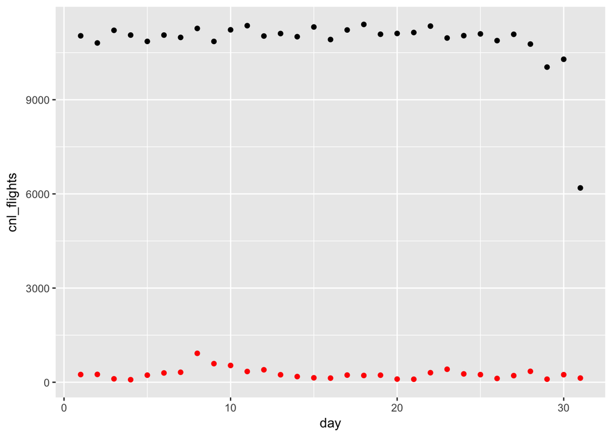

```r
ggplot(avg_day) +
  geom_point(aes(day, cnl_flights), color = "red") +
  geom_point(aes(day, all_flights))
```

### 6) What does the sort argument to count() do. When might you use it?

Answer: It can order the count by decending or ascending order

### 5 Extra Credit) Which carrier has the worst delays? Challenge: can you disentangle the effects of bad airports vs. bad carriers? Why/why not? (Hint: think about flights %>% group_by(carrier, dest) %>% summarise(n()))

Answer: Overall, F9,EV, and YV are the airlines with the worst delays (highest average delay). Adding in the airports of origin, EWR and LGA perform the worst.

```r
(flights %>%
  group_by(carrier, origin) %>%
  summarize(count = n(),
            avg_delay = mean(dep_delay, na.rm = TRUE)) %>%
  arrange(desc(avg_delay)))
```

```
## # A tibble: 35 x 4
## # Groups:   carrier [16]
##    carrier origin count avg_delay
##    <chr>   <chr>  <int>     <dbl>
##  1 OO      EWR        6      20.8
##  2 F9      LGA      685      20.2
##  3 EV      EWR    43939      20.2
##  4 EV      LGA     8826      19.1
##  5 9E      JFK    14651      19.0
##  6 YV      LGA      601      19.0
##  7 FL      LGA     3260      18.7
##  8 EV      JFK     1408      18.5
##  9 WN      EWR     6188      17.9
## 10 WN      LGA     6087      17.6
## # ... with 25 more rows
```

## Section 10.5: #1, #2, #3 and #6 only

### 1) How can you tell if an object is a tibble? (Hint: try printing mtcars, which is a regular data frame).

Answer: Printing a tibble will display the first 10 rows, then summarize the rest of the data. A dataframe will display the entire data set.

### 2)Compare and contrast the following operations on a data.frame and equivalent tibble. What is different? Why might the default data frame behaviours cause you frustration?

Answer: Data frames allow partial matching. So you can request “x” and it will return “xyz”. There may be frustration as data frames may change the type of inputs or variables and can create new row names.

```r
#output for data frame
df <- data.frame(abc = 1, xyz = "a")
print(df)
```

```
##   abc xyz
## 1   1   a
```

```r
df$x
```

```
## [1] a
## Levels: a
```

```r
df[, "xyz"]
```

```
## [1] a
## Levels: a
```

```r
df[, c("abc", "xyz")]
```

```
##   abc xyz
## 1   1   a
```

```r
#output for tibble
tbl <- as.tibble(df)
print(tbl)
```

```
## # A tibble: 1 x 2
##     abc xyz
##   <dbl> <fct>
## 1     1 a
```

```r
tbl$x
```

[output not shown]

```r
tbl[, "xyz"]
```

```
## # A tibble: 1 x 1
##   xyz
##   <fct>
## 1 a
```

```r
tbl[, c("abc", "xyz")]
```

```
## # A tibble: 1 x 2
##     abc xyz
##   <dbl> <fct>
## 1     1 a
```

### 3)If you have the name of a variable stored in an object, e.g. var <- “mpg”, how can you extract the reference variable from a tibble?

```r
var <- "mpg"
var %>% .[[1]]
```

```
## [1] "mpg"
```

### 6)What option controls how many additional column names are printed at the footer of a tibble?

Answer: n =

```r
mpg %>% print(n =10, width = Inf)
```

```
## # A tibble: 234 x 11
##    manufacturer model      displ  year   cyl trans      drv     cty   hwy
##    <chr>        <chr>      <dbl> <int> <int> <chr>      <chr> <int> <int>
##  1 audi         a4           1.8  1999     4 auto(l5)   f        18    29
##  2 audi         a4           1.8  1999     4 manual(m5) f        21    29
##  3 audi         a4           2    2008     4 manual(m6) f        20    31
##  4 audi         a4           2    2008     4 auto(av)   f        21    30
##  5 audi         a4           2.8  1999     6 auto(l5)   f        16    26
##  6 audi         a4           2.8  1999     6 manual(m5) f        18    26
##  7 audi         a4           3.1  2008     6 auto(av)   f        18    27
##  8 audi         a4 quattro   1.8  1999     4 manual(m5) 4        18    26
##  9 audi         a4 quattro   1.8  1999     4 auto(l5)   4        16    25
## 10 audi         a4 quattro   2    2008     4 manual(m6) 4        20    28
##    fl    class
##    <chr> <chr>
##  1 p     compact
##  2 p     compact
##  3 p     compact
##  4 p     compact
##  5 p     compact
##  6 p     compact
##  7 p     compact
##  8 p     compact
##  9 p     compact
## 10 p     compact
## # ... with 224 more rows
```

## Section 12.3.3: #2, #3 and #4 only

Answer: 1999 and 2000 need tick marks as they are non-syntactic names which don’t start with a letter.

Answer: each row needs to be a separate observation. In this case, “Phillip Woods” has two ages. You can add a separate columne for date that has a unique age.

### 4) Tidy the simple tibble below. Do you need to spread or gather it? What are the variables?

Answer: Gather. Variables are “pregnant” and “gender”

```r
preg <- tribble(
  ~pregnant, ~male, ~female,
  "yes",     NA,    10,
  "no",      20,    12
)

tidyup <- gather(preg, key = gender, male, female, value = count)

glimpse(tidyup)
```

```
## Observations: 4
## Variables: 3
## $ pregnant <chr> "yes", "no", "yes", "no"
## $ gender   <chr> "male", "male", "female", "female"
## $ count    <dbl> NA, 20, 10, 12
```

## Section 12.4.3: #1 and #2 only

### 1) What do the extra and fill arguments do in separate()?

Answer: Extra addresses the instances where there are more values than there are columns. You can choose to remove or merge the extra values. Fill addresses instances where there are not enough values to fill all of the defined columns. You can fill to the left or right to duplicate values to fill those values.

```r
tibble(x = c("a,b,c", "d,e,f,g", "h,i,j")) %>%
  separate(x, c("one", "two", "three"))
```

```
## # A tibble: 3 x 3
##   one   two   three
##   <chr> <chr> <chr>
## 1 a     b     c
## 2 d     e     f
## 3 h     i     j
```

### 2) Both unite() and separate() have a remove argument. What does it do? Why would you set it to FALSE?

Answer: The remove argument if set to FALSE, will keep the existing column and adds the separated values (or united values). You may need to keep the existing calculation (using separate) or keep the old columns (using unite) if you need those values elsewhere instead of replacing them.

```r
table3 %>%
  separate(rate, into = c("cases", "population"), remove = FALSE)
```

```
## # A tibble: 6 x 5
##   country      year rate              cases  population
## * <chr>       <int> <chr>             <chr>  <chr>
## 1 Afghanistan  1999 745/19987071      745    19987071
## 2 Afghanistan  2000 2666/20595360     2666   20595360
## 3 Brazil       1999 37737/172006362   37737  172006362
## 4 Brazil       2000 80488/174504898   80488  174504898
## 5 China        1999 212258/1272915272 212258 1272915272
## 6 China        2000 213766/1280428583 213766 1280428583
```

## Answer these questions:

### Follow these steps:

#### - Download the baby_names.txt file from Canvas which is in the Homework 4 assignment section.

#### - Load this file into R correctly and take a glimpse of the output.

#### - Export this file as a csv file and call it ‘baby_names.csv’.

#### - Reload the baby_names.csv file and take another glimpse.

#### - Show all of your code and the output. There should be two data import lines of code, one data export line of code, and two glimpses of the data.

```r
#Import txt file
file_path <- '/users/jalee/desktop/baby_names.txt'
csv_data <- read_csv(file = file_path)
#glimpse txt file
glimpse(csv_data)
```

```
## Observations: 30,000
## Variables: 1
## $ `year|sex|name|n|prop` <chr> "1880|F|Mary|7065|0.0723843285111266", ...
```

```r
#export to csv
write.csv(csv_data, "/users/jalee/desktop/baby_names.csv")

#Import csv file
file_path_csv <- '/users/jalee/desktop/baby_names.csv'
csv_data1 <- read_csv(file = file_path_csv)
#glimpse csv file
glimpse(csv_data1)
```

```
## Observations: 30,000
## Variables: 2
## $ X1                     <int> 1, 2, 3, 4, 5, 6, 7, 8, 9, 10, 11, 12, ...
## $ `year|sex|name|n|prop` <chr> "1880|F|Mary|7065|0.0723843285111266", ...
```